# Chapter3_ideas

April Peterson

09 January 2020

# Within Nuc covariation

Main take away from Wang et al 2019 is that chromosomes with the same nucleus co-vary in number of crossovers. Axis lengths / SC lengths show the same pattern and is known to be regulated at the cell wide level. The authors suggest that the within nucleus co-variation in CO per chromosome is mediated through cell wide regulation of SC area. (the lengths of SC for chromosomes within a cell a correlated, there is more area for COs).

human Data used in the paper

Gruhn et al 2013 - T. Hassold, 4660 prophase sperm from 56 biopsies, 2000 prophase oocytes

Sun et al 2006 – F. Sun, 824 MLH1 FISH spreads(~100 cells / 10 men)

Oliver-Bonet et al 2007 – Oliver- Bonet (RPA foci for 5 different SCs ~50 cells, ~400 cells with FISH + MLH1). problem if these data are included in big dataset

Lian et al 2008 - S. Xie, (maybe similar data as sun et al 2008?) Lian, Jie, et al. “Variation in crossover interference levels on individual chromosomes from human males.” Human molecular genetics 17.17 (2008): 2583-2594.

Lu et al 2012 - Hou et al 2013 - no SC lengths, (CO sounts 68 cells (oocytes?))

Human data are from mulitple citations; Gruhn et al 2013, Sun et al 2006, Oliver-Bonet et al 2007, Lian et al 2008, Lu et al 2012, Hou et al 2013.

Cytological Studies of Human Meiosis: Sex-Specific Differences in Recombination Originate at, or Prior to, Establishment of Double-Strand Breaks

Was there original CO position data for this human data? (MLH1 spreads) (there is axis length and CO count per chrm – this should mean there is position )

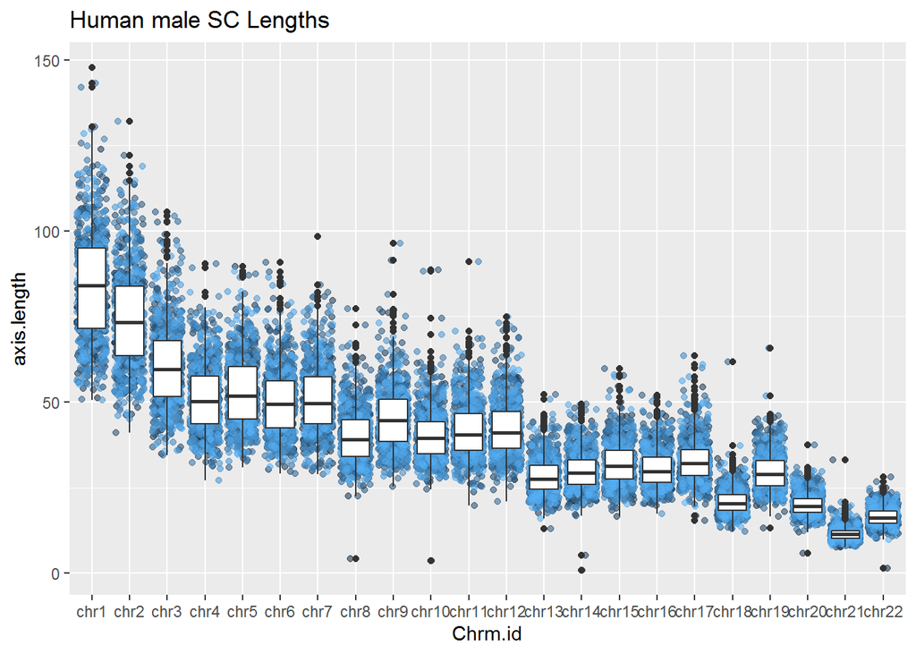

## Permutations of Human Data

Heads of the cell-wide summary statistics.

```
##   row.name nbivs n.CO  mean.CO    cV.CO
## 1        1    22   38 1.727273 47.88083
## 2        2    22   47 2.136364 36.24463
## 3        3    22   36 1.636364 51.80459
## 4        4    22   45 2.045455 31.92437
## 5        5    22   38 1.727273 44.42245
## 6        6    22   52 2.363636 30.74633
```

```
##   row.name nbivs total.SC  mean.SC    cV.SC
## 1        1    22 616.6242 28.02837 53.14099
## 2        2    22 824.3285 37.46948 49.90417
## 3        3    22 755.2252 34.32842 42.05253
## 4        4    22 782.4250 35.56477 45.65452
## 5        5    22 691.5828 31.43558 41.93370
## 6        6    22 780.0574 35.45715 43.43160
```

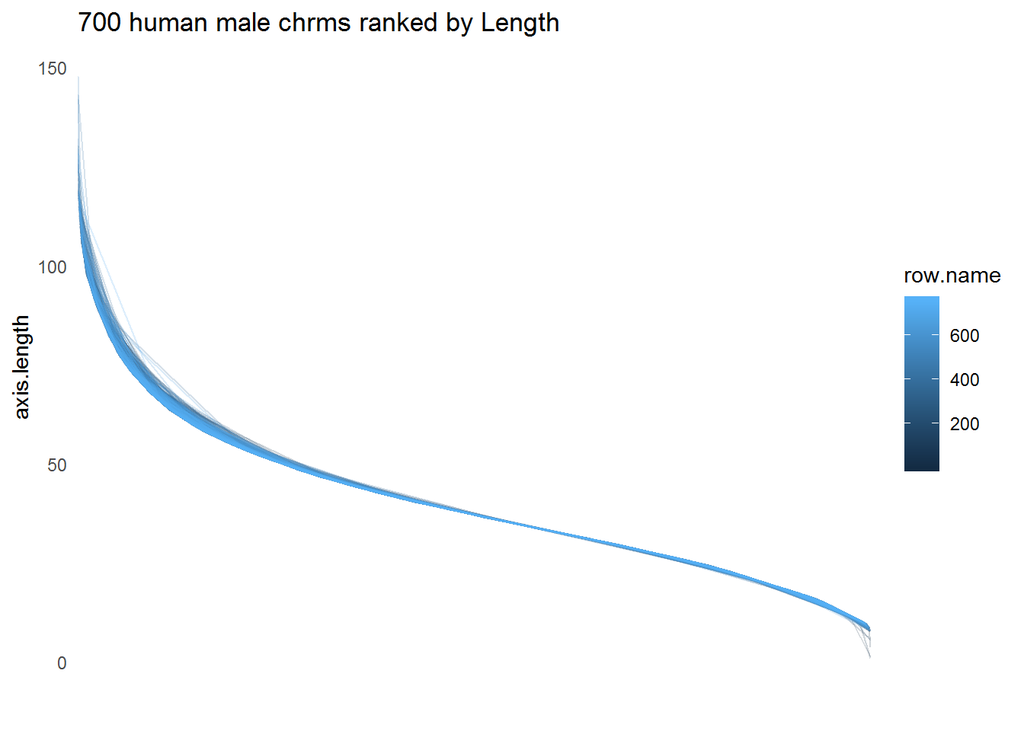

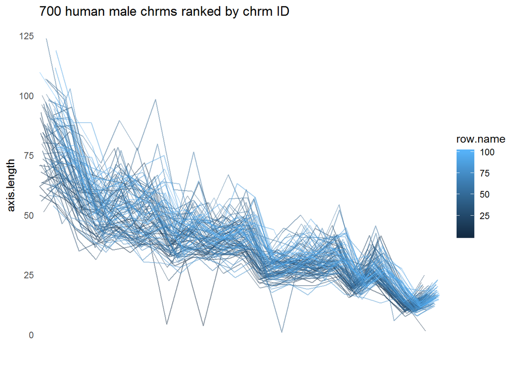

I’m trying to think more about the single cell looping factor. – how would I discribe this, slope of ranked Sometimes the chrm id doesn’t fit rank expectations. (looking at the mini.biv plots, )

I ran two types of permutations for the CO count per cell data. ‘sim no rank’ is a dataset where chromosome CO counts were drawn from the entire pool of chromosome observations. ‘Sim w.rank’ is a randomized pool, but each cell is made of random draws from one of each of the chromosome bins.

I didn’t test the axis length trait yet. (See below for axis traits)

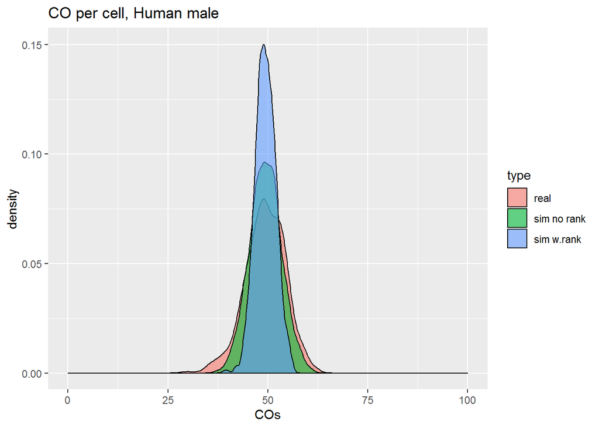

Qualitatively these results look the same as in the Wang et al 2019 paper. I haven’t confirmed the calculations with a variability index. To calculate the ‘variability index’, the authors take the percentage of cells (or integrated curve area) which differ between the empirical and simulated distributions. I still need to do some work to make sure I can calculate the differences in distributions.

The rank distinction is to test if sampling within pools of specific chromosomes makes a difference. The smaller/tighter distribution between CO count per nuc with the ranked and non-ranked distributions indicate there is a small chromosome specific effect.

# Mus whole Cell Data Set

Show a plot of the estimates chrm sizes. These values from MGI page omit centromere and telomere estimates. Read up on the T2T project lit to see if I can find better estimates of physical chormosome sizes.

Do I need most accurate estimate of Mb size variance? would I expect – similar variance among cells? If i ran jack-knifing or sub-sampling permutations of the within cell covariance calculations – if the covariation eatimate remained about the same, I would be more convinced that the ‘packing’ ratio is mostly uniform WITHIN cells. Null/ comparison value might be, randomize cell.id for all bivalent observations. (maybe I should first try this in human data? (minus the wacky looking cells / bad chrm id))

This might be the best thing to do to account for different physical sizes across other strains (non reference genome)

The whole cell comparisons (from empirical and randomized distributions): - CO counts per cell - Total SC per cell (calculated by single bivalents) - CO position (cell wide rbar, mean telomere bias)

The CO position metrics might change.

```
##
##    WSB female      WSB male      G female        G male    LEW female
##            60            57            60            95            58
##      LEW male     PERC male    PWD female      PWD male    MSM female
##            76             0            60            57           119
##      MSM male   MOLF female     MOLF male  SKIVE female    SKIVE male
##           133             0             0             0             0
##    KAZ female      KAZ male  CZECH female    CZECH male      AST male
##             0             0             0             0             0
##      TOM male   CAST female     CAST male    HMI female      HMI male
##             0             0            38             0             0
##  SPRET female    SPRET male   SPIC female     SPIC male CAROLI female
##             0             0             0             0             0
##   CAROLI male            F1         other
##             0             0             0
```

ratios now 2.2573609, 2.7674649, 2.4327866, 2.9813988, 3.4137773, 3.8973454, 3.5015639, 2.938042, 1.6939795, 3.1914256, 3.4284963, 1.0461388, 3.9302475, 3.2063239, 3.8718837, 2.0471998, 1.4459889, 5.3910258

0.4429952, 0.3613415, 0.4110513, 0.335413, 0.2929306, 0.2565849, 0.2855867, 0.3403627, 0.5903259, 0.3133396, 0.2916731, 0.9558961, 0.2544369, 0.3118836, 0.2582722, 0.4884721, 0.6915683, 0.1854935

Calculated the ratio of genome size variance (haploid chrm variance), (I think the right denominator is SC length variance) most all are above 1 (for both female and male) – indicates the packing ratio / packing process doesn’t maintain (our guess about genome size of chromosomes)

I calculate within cell ranked SC length to use rank as a proxy for chromosome ID for bivalents.

Below are plots of the SC distributions across the rank

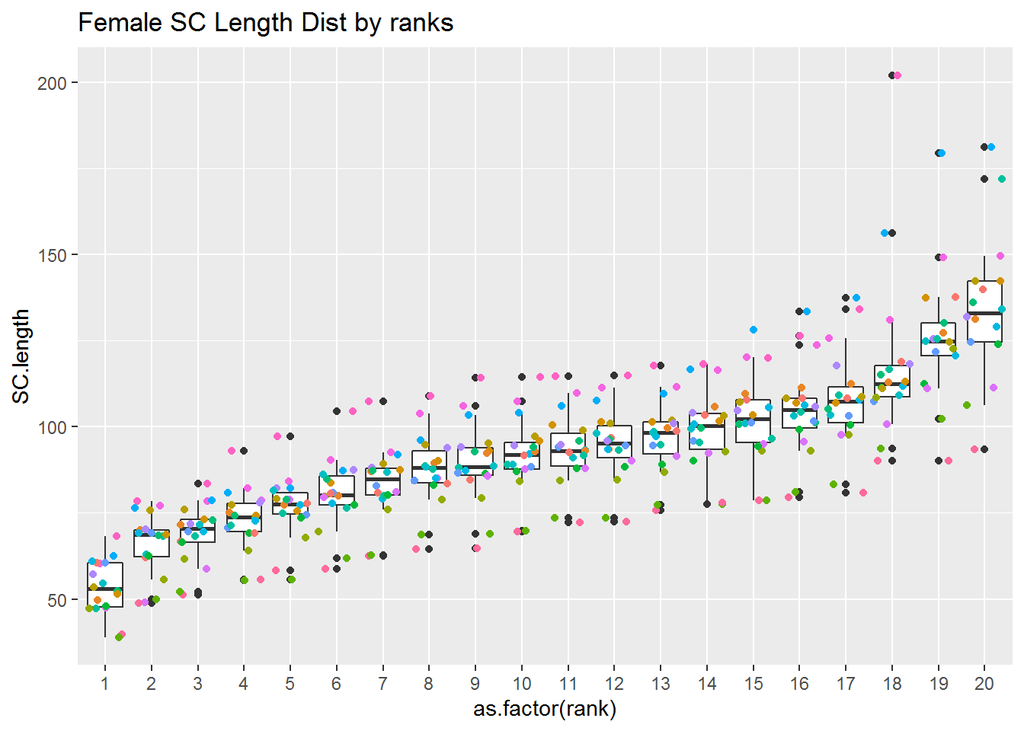

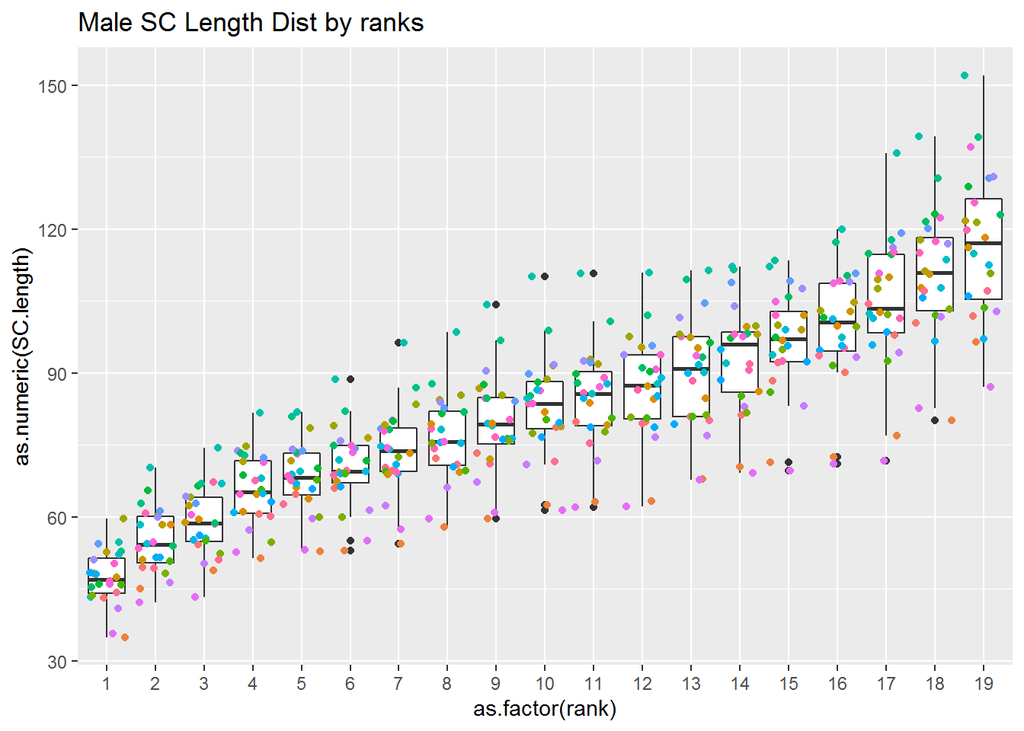

The plots above look much different than when I first made them. The SC values might not be right.

# Mus Permutation Setup

I will make the permuted data sets once and display the summary stats (and compare the empirical to random distribution).

I will us the same rank and non-ranked version of permutations as I did for the human data. Since I don’t have chromosome IDs, I will use the within cell SC length ranks as a proxy for chromosome identity (rank).

## CO count, male

Theses code chunks make a data set of 24 nuclei with 19 random chromosome draws each.

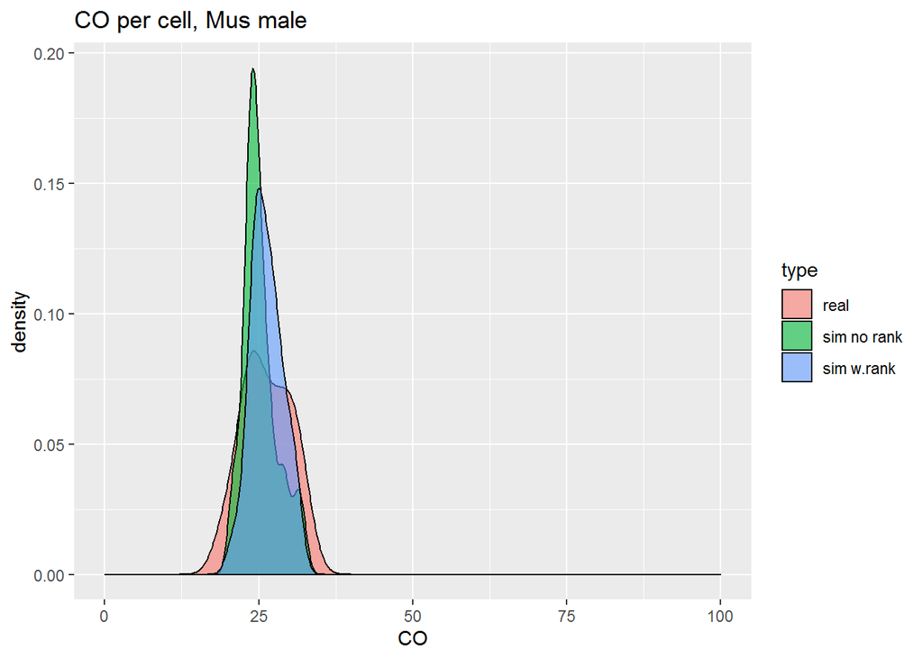

Above plot shows over dispersion of CO counts per cell for my Mus male data set. The above plot the real data might have more variance because it’s a combination of strains

## CO count, female

For mus, data frames that sample based on SC.length / rank, can be used for SC length and CO count metrics. Not CO position

both SC and CO count randomized data

These code chunks make a randomized data set of 18 nuclei with 20 random chromosome draws each.

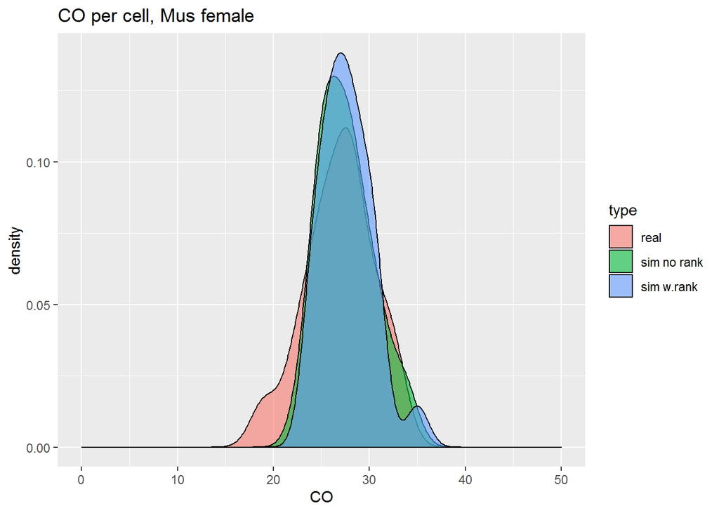

Density plot above also shows that the female CO count data is over dispersed compered to a randomized distribution.

# SC length, bivalent level

Comparing cell wide statistics for SC lengths across the real and randomized data sets.

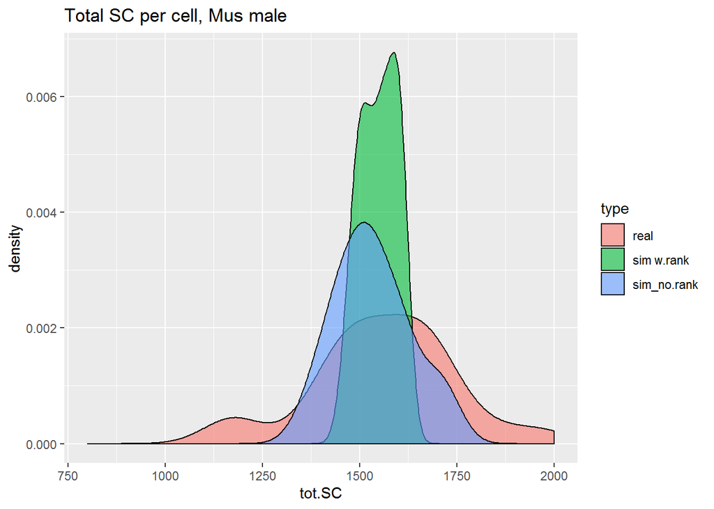

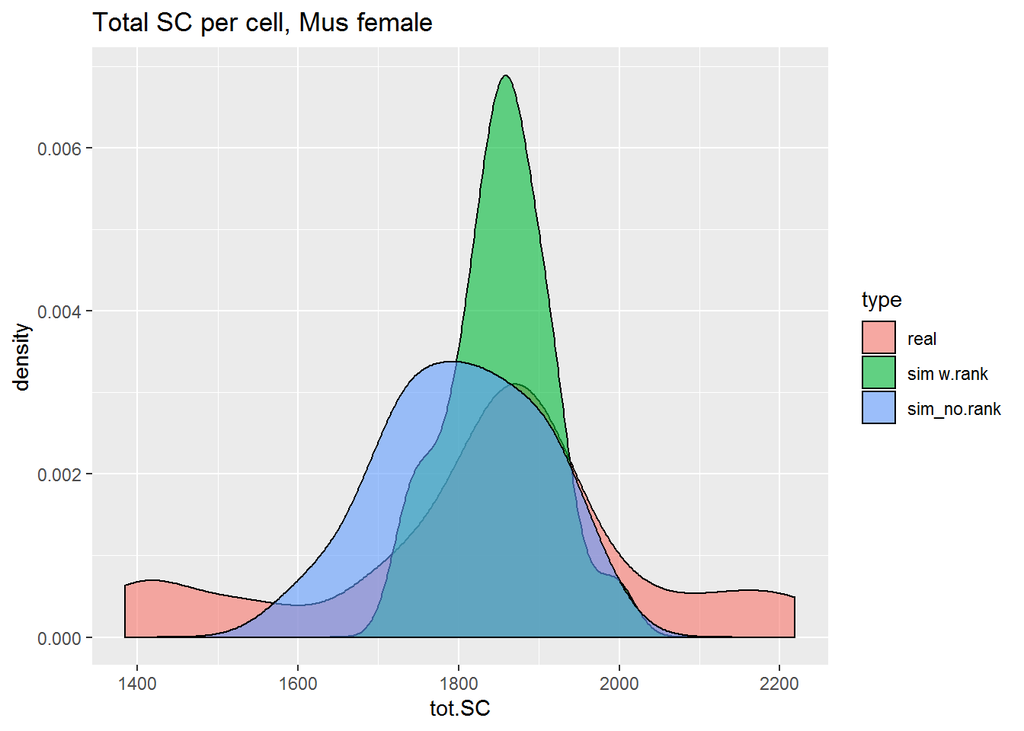

The distribution of the female SC lengths isn’t normal. Double check these values – if their hand measured, not sure why 1 has much lower sc lengths.

I think the difference in variance of the rank and non-rank suimulations shows that chromsomes effects play a bigger role in shaping the distributions of cell wide SC area.

# CO Position

I think new randomized DFs must be made (male.whole.cell.min, not the DF.list) (previous ones made lists of DFs, which were made of simulated DFs for each nucleus/cell) My current code for position data, takes the current real DF, adds new columns with random draws of relative CO positions.

I am still working on the metrics to compare (and the ones that are best for cell wide descriptions). - cell wide telomere bias - cell wide rbar (smaller values mean more equal chrm proportions between foci. ) - average IFD

(should these metrics should be weighted by CO count?)

-measure the CO-variation of metrics within cells! for each cell, make even-rank and odd-rank columns of rbar or another metric. Measure covariance of the 2 sets of pairs (real and random, even-odd).

## Male CO Position

Comparing cell wide statistics for CO position metrics across the real and randomized data sets.

The permuted/randomized data set is made by keeping CO count and SC lengths constant, but replacing the normalized foci position with a random normalized foci position(s) drawn from a pool of the same CO counts. The randomized relative positions are converted into raw/absolute positions (for the original SC length of that bivalent observation).

### calq within nuc COVARIATION

```
## [1] 303.3798
```

```
## [1] 0.9829839
```

```
## [1] 0.007357481
```

```
## [1] 0.9734986
```

Calq the within cell covariance for the true and randomized values. Not sure how to use them yet

### merge melt data

don’t use melt data

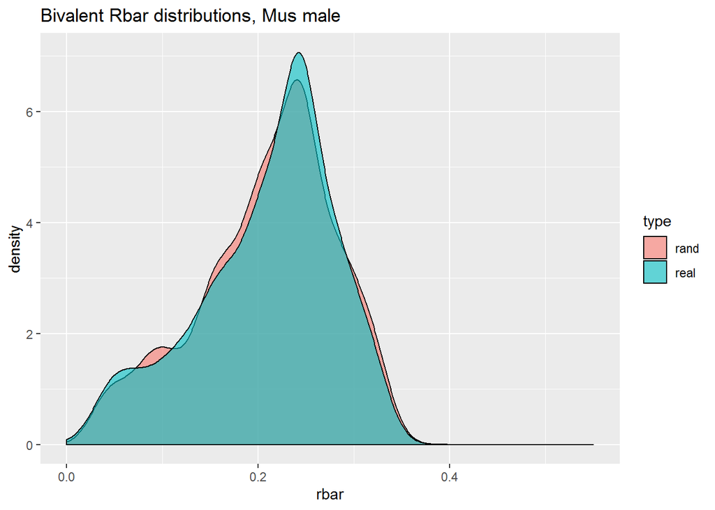

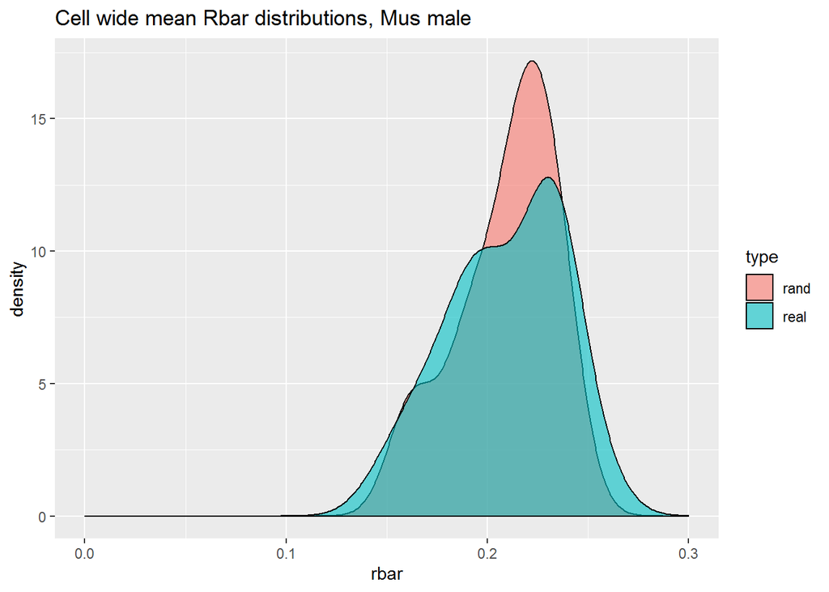

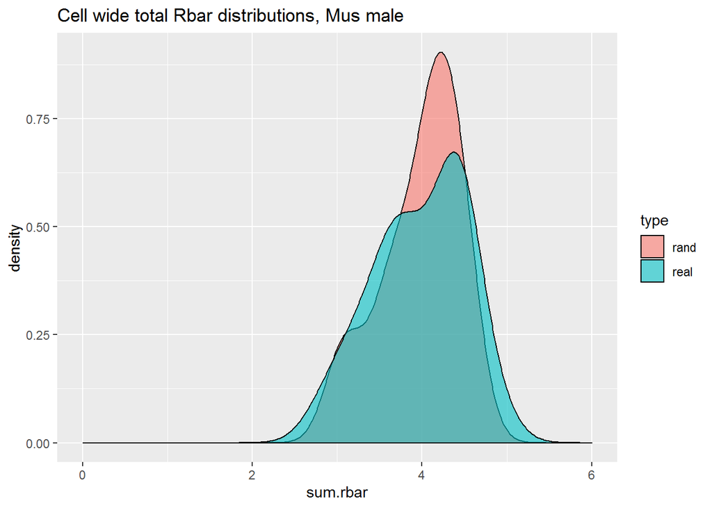

The random relative foci positions were ‘mapped’ onto each of the SC length observations (foci * SC.length).

The first plot shows the 2 disttributions of all the rbar measures (across all bivalents) The second plot shows the mean rbar for the whole cell

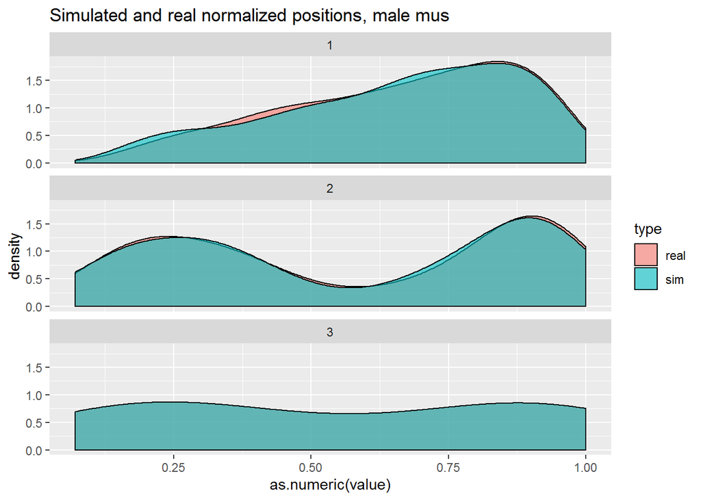

The above distributions of relative foci position compare the real data pink to randomized data set of relative positions where for each bivalent observations the normalized position was replaced with positions from a randomly draw bivalent with the same CO number. For multi co bivalents relative foci positions were kept together. For example, a random 2CO bivalent chosen and the normalize foci1 and foci2 for that bivalent were used. In terms of normalized foci positions, the empirical distribution isn’t very different from a randomized distribution. Not exactly sure if this is the right randomization procedure, the same ‘random’ bivalent could be drawn more than once.

I might write in a way to account for rank, to account for how the relative foci positions vary for short and long chromosomes. but for now, just simulate across the whole/full pool.

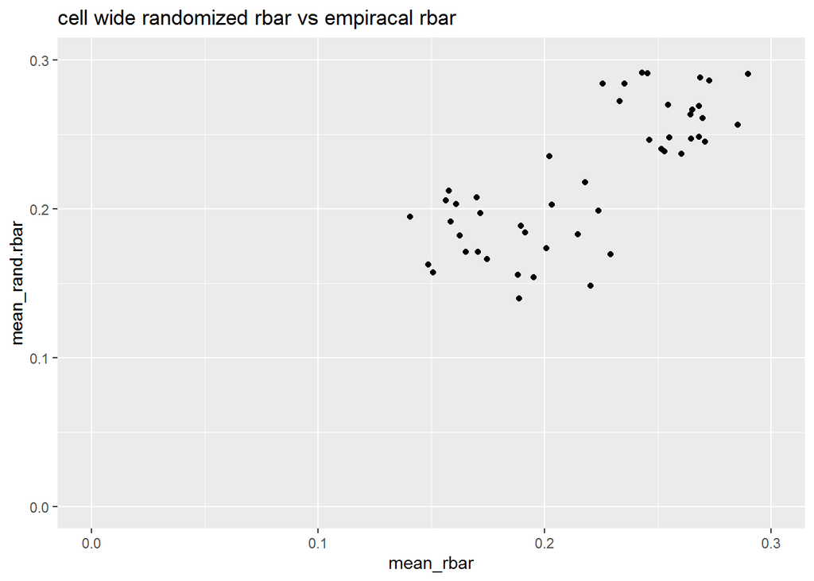

distributions don’t look different. Since I randomized the cell effect – I need to map back into a cell wide summary to effectively compare the differences.

NEED to Calculate cell-wide telomere bias (use a ddplyr thing)

some of the plots compare the cell wide measures from real and randomized (I think this difference is what I should calculate for permuting or randomizing)

points closer to 1:1 line have foci position features near the average of the group

the random r bar is higher than the real r bar positions. meaning on average the male cell rbar values are lower (less to the middle and more to the ends) – would this be the same as in female cells?

we calculated the intra-chromosomal portion of rbar (Veller et al., 2019) to compare how evenly crossovers were spaced while accounting for raw SC length. This metric ranges from 0 to 0.5, with higher values indicating that SC proportions flanking crossovers are more equivalent.

My randomized plots indicate that the real chromosome measures have more ‘unequal’ chromsome portions flanking COs.

## Female CO Position Comparison

For now stick with rbar, since it’s a metric I can use across chromosome classes.

1. randomized
2. calq rbar values
3. merge mini.DFs
4. plot

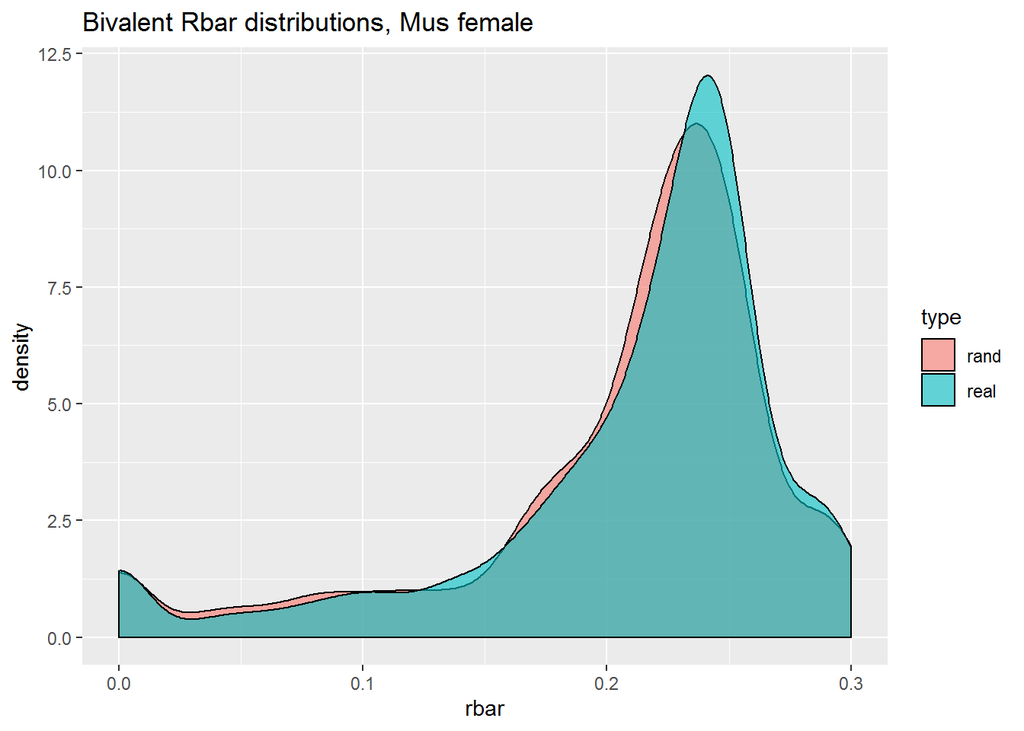

Not sure why real distribution is more smooth compared to the random. The female rbar measures are closer to the maxium of 0.5, where all foci are placed equally along the chromsomes.

## Adding to Data set

how to best increase the size of the data set, with my bivalent data. From the curated BivData, figure out which can be added / into the whole cell data. I think there might only be a couple cell to add in.

Look/use the DF, Curated_BivData data frame for mice with many cell measures and cells with whole cell measures (all bivalents have been measured).

Mice with many cells and BivData 17mar16_G_f4 - BivData 17mar16_G_f1

Chunk below has code for choosing mice with a good number of cells (25?)